# Claude Code Skills for Clinical Trial Design

2026-03-14

## Agenda (40-45 min)

| Time | Topic |
| --- | --- |
| 5 min | What are Claude Code Skills? |
| 5 min | The graphicalMCPgsd2 skill — overview |
| 10 min | Live demo: design specification workflow |
| 10 min | Live demo: simulated results and testing |
| 5 min | Key pitfalls the skill prevents |
| 5 min | Creating and customizing your own skills |
| 5 min | Q&A |

## Part 1: What Are Claude Code Skills?

## Claude Code — Quick Refresher

- **Claude Code** is Anthropic’s CLI for AI-assisted software engineering
- You interact with Claude in your terminal; it can read/write files, run code, search, etc.
- Works in any language and framework — including R

**The challenge**: Claude is a generalist. For specialized domains (like clinical trial design), it may not know your team’s conventions, preferred packages, or subtle API pitfalls.

## What Is a Skill?

A **skill** is a structured knowledge package that teaches Claude how to perform a specific task well.

Think of it as: **a domain expert’s notes, organized for an AI assistant**

```
my-skill/
├── SKILL.md          # Instructions + when to trigger
└── references/       # Detailed code patterns, docs
    └── code_patterns.md
```

## How Skills Work

**Three-level loading system:**

1. **Name + description** — always in context (~100 words)
   - Claude reads this to decide: “Should I use this skill?”
2. **SKILL.md body** — loaded when skill triggers (~500 lines)
   - Workflow overview, key decisions, important caveats
3. **Reference files** — loaded on demand (unlimited)
   - Detailed code templates, API patterns, edge cases

This keeps Claude’s context focused while providing deep knowledge when needed.

## When Does a Skill Trigger?

The `description` field in SKILL.md frontmatter controls triggering:

```yaml
---
name: graphicalMCPgsd2
description: >
  Guide users through group sequential design with
  graphical multiplicity control using the graphicalMCP
  and gsDesign2 R packages. Use this skill whenever
  the user asks about: group sequential designs with
  multiple hypotheses, sequential p-values, ...
---
```

Claude matches user requests against these descriptions and loads the skill when relevant.

## Skills vs. Prompt Engineering

|  | Ad-hoc prompting | Skills |
| --- | --- | --- |
| **Persistence** | Lost each session | Saved permanently |
| **Consistency** | Varies by prompt | Same patterns every time |
| **Depth** | Limited by context | Progressive disclosure |
| **Sharing** | Copy-paste | Install once, use everywhere |
| **Validation** | Manual checking | Tested with benchmarks |

Skills encode **institutional knowledge** so every team member gets the same expert guidance.

## Part 2: The graphicalMCPgsd2 Skill

## What This Skill Does

Guides Claude through the **Maurer-Bretz (2013) framework** for clinical trials with:

- Multiple endpoints (OS, PFS, ORR)
- Multiple populations (BM+ subgroup, Overall)
- Group sequential designs with interim analyses
- Graphical multiplicity control for FWER

**Packages**: `graphicalMCP`, `gsDesign2`, `wpgsd`

## The Four-Phase Workflow

The skill teaches Claude a structured workflow:

| Phase | What happens | Key functions |
| --- | --- | --- |
| **1. Design** | Define hypotheses, build graph, size trial | `graph_create()`, `gs_design_ahr()`, `gs_power_ahr()` |
| **2. Results** | Record events, nominal p-values, spending time | Data entry template |
| **3. Testing** | Compute sequential p-values, test graph | `sequential_pval()`, `graph_test_shortcut()` |
| **4. Verification** | Update bounds, confirm rejections | `gs_update_ahr()`, `graph_update()` |

## Skill File Structure

```
graphicalMCPgsd2/
├── SKILL.md
│   ├── When to use this skill
│   ├── Required packages
│   ├── Workflow overview (4 phases)
│   └── Important design considerations
└── references/
    └── code_patterns.md
        ├── Multiplicity graph setup
        ├── Sample-size-driving design
        ├── Enrollment derivation
        ├── Power for remaining hypotheses
        ├── Results entry template
        ├── Sequential p-values
        ├── Hypothesis testing
        ├── Verification with updated bounds
        ├── P-value computation (logrank, RD)
        ├── Theoretical survival curves
        ├── Kaplan-Meier plots
        └── WPGSD analysis
```

## The Example Trial Design

6 hypotheses: 3 endpoints \(\times\) 2 populations

| Hypothesis | Endpoint | Population | Analyses | Initial \(\alpha\) |
| --- | --- | --- | --- | --- |
| H1 | OS | BM+ | 3 | 0.0100 |
| H2 | OS | Overall | 3 | 0.0100 |
| H3 | PFS | BM+ | 2 | 0.0040 |
| H4 | PFS | Overall | 2 | 0.0000 |
| H5 | ORR | BM+ | 1 | 0.0005 |
| H6 | ORR | Overall | 1 | 0.0005 |

Total FWER = \(\sum \alpha_i\) = 0.025 (one-sided)

## The Multiplicity Graph

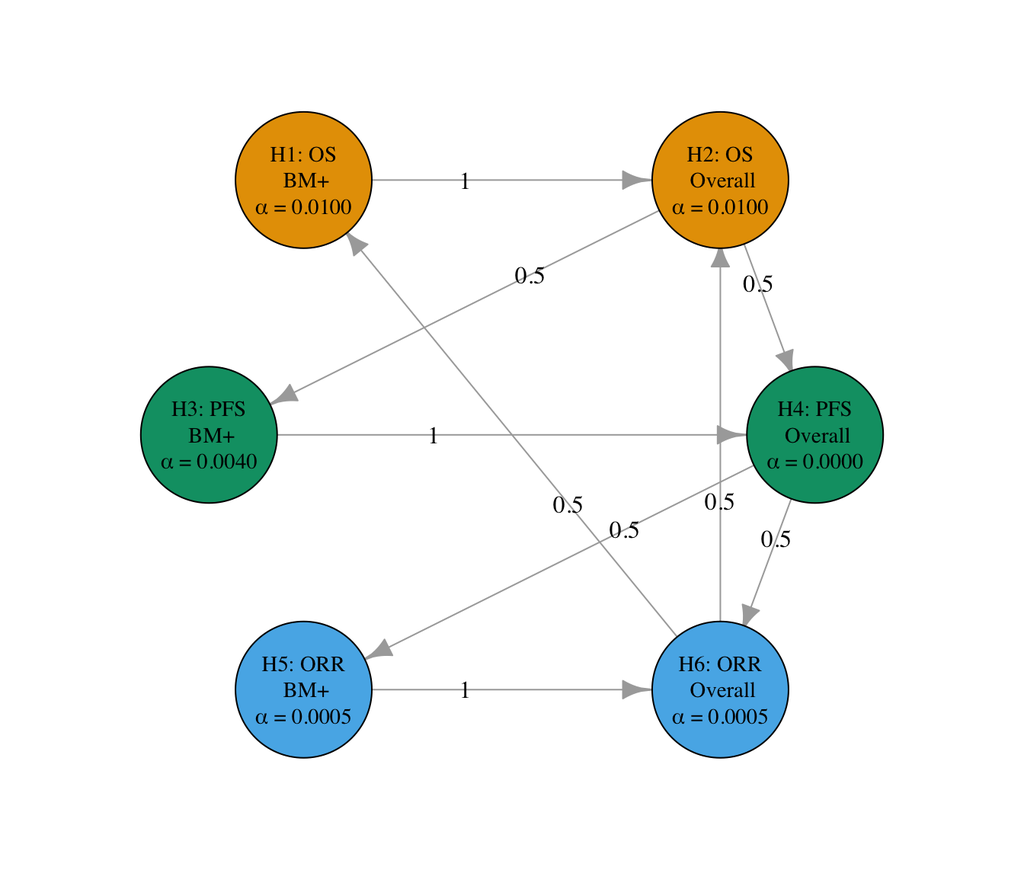

## Part 3: Design Specification

## H1 Drives Sample Size

One hypothesis drives the entire trial size — typically **OS in the subgroup (H1)**:

```r
ossub <- gsDesign2::gs_design_ahr(
  enroll_rate = enroll_rate_sub_init,
  fail_rate = fail_rate_os_sub,
  alpha = alphaHypotheses[1],   # H1's alpha
  beta = 0.1,                    # 90% power
  analysis_time = c(20, 28, 38), # Calendar months
  info_frac = NULL,              # Derived from timing
  info_scale = "h0_info",
  upper = gsDesign2::gs_spending_bound,
  upar = list(sf = gsDesign::sfLDOF,
              total_spend = alphaHypotheses[1]),
  test_lower = FALSE
)
```

## Key Design Pattern: `info_frac = NULL`

**Without the skill**, Claude often passes `info_frac` directly:

```r
# WRONG — gs_power_ahr() doesn't accept info_frac
gs_power_ahr(info_frac = c(0.5, 0.8, 1), ...)
```

**With the skill**, Claude knows to use `analysis_time` and let the information fraction be derived:

```r
# CORRECT — timing drives the information fraction
gs_power_ahr(
  analysis_time = c(20, 28, 38),
  event = NULL,  # Must be NULL!
  info_scale = "h0_info", ...
)
```

## Deriving Enrollment from H1

All other hypotheses derive their enrollment from H1:

```r
enroll_rate_sub <- ossub$enroll_rate
n_sub <- sum(enroll_rate_sub$rate * enroll_rate_sub$duration)
n_complement <- n_sub * (1 - prevalence) / prevalence

# Stratified enrollment for Overall population
enroll_rate_overall <- gsDesign2::define_enroll_rate(
  stratum = rep(c("BM+", "BM-"),
                each = nrow(enroll_rate_sub)),
  duration = rep(enroll_rate_sub$duration, 2),
  rate = c(enroll_rate_sub$rate,
           enroll_rate_sub$rate *
             (1 - prevalence) / prevalence)
)
```

## Power for Remaining Hypotheses

```r
# Time-to-event: gs_power_ahr() (not gs_design_ahr!)
pfssub <- gsDesign2::gs_power_ahr(
  enroll_rate = enroll_rate_sub,
  fail_rate = fail_rate_pfs_sub,
  event = NULL,          # Let analysis_time drive it
  analysis_time = c(20, 28), ...
)

# Binary (ORR): fixed_design_rd()
orr_sub <- gsDesign2::fixed_design_rd(
  alpha = alphaHypotheses[5],
  power = NULL,          # Compute power
  p_c = 0.30, p_e = 0.45,
  n = ceiling(n_sub) * 2
)
```

## Zero Initial Alpha Workaround

H4 (PFS Overall) starts with \(\alpha = 0\) — receives alpha only through reallocation.

```r
# This would ERROR — alpha = 0 breaks spending function
gs_power_ahr(
  upar = list(sf = gsDesign::sfLDOF,
              total_spend = 0), ...  # Can't spend 0!
)

# The skill knows: use another hypothesis's alpha
# for the bounds structure
gs_power_ahr(
  upar = list(sf = gsDesign::sfLDOF,
              total_spend = alphaHypotheses[3]), ...
)
```

The actual testing uses the reallocated alpha from the graph.

## Part 4: Results and Testing

## Illness-Death Simulation Model

The vignette uses a **competing risks illness-death model** to simulate realistic trial data with piecewise exponential transitions via `simtrial::rpwexp()`, numerically calibrated to match marginal PFS/OS medians using `uniroot()`.

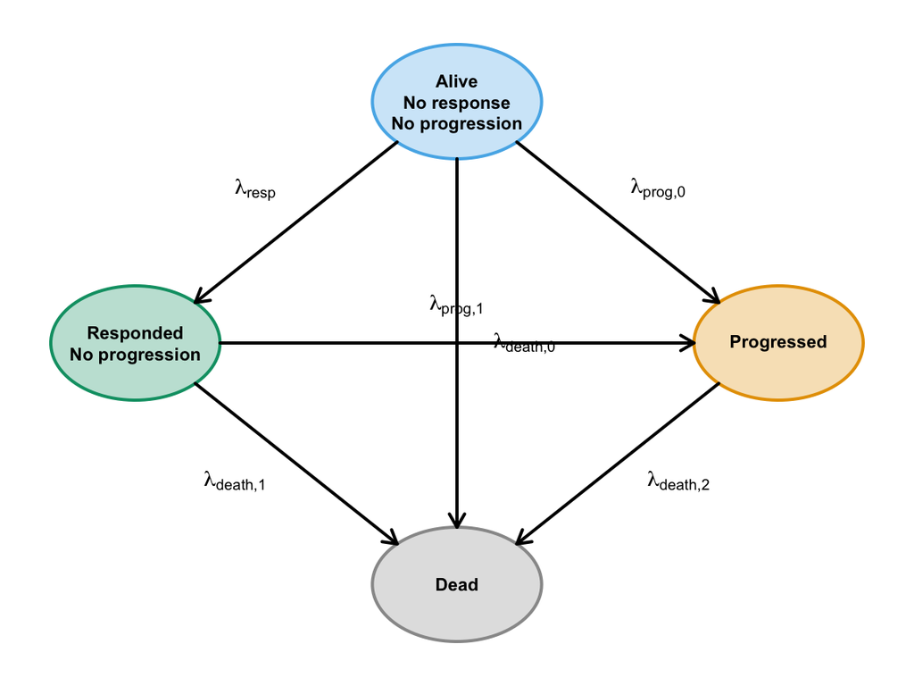

## Theoretical Survival Curves

From the illness-death model parameters, compute **marginal PFS and OS** analytically (no simulation needed):

```r
get_theoretical_surv <- function(transition_rate,
                                  stratum_val, trt_val, t_grid) {
  # Extract rates, compute marginal CDF via .pfs_cdf() / .os_cdf()
  pfs_surv <- 1 - sapply(t_grid, function(t)
    .pfs_cdf(t, lambda_0, orr_param, lambda_1))
  os_surv  <- 1 - sapply(t_grid, function(t)
    .os_cdf(t, lambda_0, orr_param, lambda_1, ...))
}
```

**2×2 layout**: Top row shows by-stratum curves (BM+ solid, BM- dashed); bottom row shows the overall population (weighted: 60% BM+ + 40% BM-).

```r
# Overall = prevalence-weighted mixture
overall_surv <- bm_prev * surv_BM_pos + (1 - bm_prev) * surv_BM_neg
```

This validates design assumptions before any simulation.

## P-Value Computation

### 1-sided logrank test (OS, PFS)

```r
logrank_pval <- function(data, stratified = FALSE) {
  data$event <- 1L - data$CNSR
  fit <- survdiff(Surv(AVAL, event) ~ TRT +
    strata(STRATUM), data = data)
  # CRITICAL: with strata, obs/exp are MATRICES
  obs_ctrl <- if (is.matrix(fit$obs))
    sum(fit$obs[1, ]) else fit$obs[1]
  exp_ctrl <- if (is.matrix(fit$exp))
    sum(fit$exp[1, ]) else fit$exp[1]
  z_sign <- sign(obs_ctrl - exp_ctrl)
  z <- z_sign * sqrt(fit$chisq)
  pnorm(-z)
}
```

## The `survdiff` Stratification Pitfall

**Without the skill:**

```r
# BUG: fit$obs[1] gives first stratum only!
z_sign <- sign(fit$obs[1] - fit$exp[1])
# Gives WRONG p-values for stratified tests
```

**With the skill:**

```r
# CORRECT: sum across strata
obs_ctrl <- if (is.matrix(fit$obs))
  sum(fit$obs[1, ]) else fit$obs[1]
```

This bug produces p-values near 0.5 or 1.0 instead of the correct small p-values when treatment is effective. The skill documents this pitfall explicitly.

## Stratified Risk Difference (ORR)

For the Overall population, stratify by BM+/BM- with sample size weights:

```r
rd_pval <- function(data, stratified = TRUE) {
  strata <- unique(data$STRATUM)
  for (k in seq_along(strata)) {
    # Compute per-stratum rate difference and variance
    rd_s[k] <- p_exp - p_ctrl
    var_s[k] <- p_exp*(1-p_exp)/n_exp + p_ctrl*(1-p_ctrl)/n_ctrl
    n_s[k] <- n_exp + n_ctrl
  }
  w <- n_s / sum(n_s)           # Sample size weights
  rd_combined <- sum(w * rd_s)
  se_combined <- sqrt(sum(w^2 * var_s))
  z <- rd_combined / se_combined
  pnorm(-z)  # 1-sided: small when experimental better
}
```

## Spending Time vs Information Fraction

Two related but different quantities:

| Concept | What it controls | Formula |
| --- | --- | --- |
| **Spending time** | How \(\alpha\) is allocated across analyses | Typically: \(d_{\text{sub},k} / d_{\text{sub},K}\) |
| **Info fraction** | Correlation structure between analyses | \(d_k / d_K\) for each hypothesis |

**Key rule**: Use the **subgroup** information fraction as spending time for ALL hypotheses (both subgroup and overall).

Spending time must reach 1.0 at the final analysis.

## Sequential P-Values

```r
for (h in 1:nHypotheses) {
  EOCtab$seqp[h] <- ifelse(
    is.null(gsD2list[[h]]),
    # Non-GSD: nominal p-value IS the sequential p
    EOCtab$nominalP[h],
    {
      tem <- filter(inputResults, H == h)
      gsDesign2::sequential_pval(
        gs_design = gsD2list[[h]],
        event = tem$events,
        z = -qnorm(tem$nominalP),
        ustime = tem$spendingTime,
        interval = c(1e-05, 0.9999)
      )
    }
  )
}
```

## Graphical Testing

```r
result <- graphicalMCP::graph_test_shortcut(
  graph = g0,
  p = EOCtab$seqp,   # Sequential p-values
  alpha = fwer,       # Total FWER (0.025)
  verbose = TRUE
)
```

**Shortcut test** (Bonferroni-based):

- Tests each hypothesis against its allocated \(\alpha\)
- When a hypothesis is rejected, reallocates its \(\alpha\) per the transition matrix
- Ignores correlations between test statistics

## WPGSD: Accounting for Correlations

The **wpgsd** package exploits known correlations for less conservative bounds:

1. **Group sequential correlation**: \(\text{corr}(Z_{A_s}, Z_{A_t}) = \sqrt{d_{\min(s,t)} / d_{\max(s,t)}}\)
2. **Population-induced correlation**: Since BM+ \(\subset\) Overall, the intersection of events = BM+ events

```r
corr <- wpgsd::generate_corr(event_table)

bound_wpgsd <- wpgsd::generate_bounds(
  type = 3, k = n_analyses,
  w = w, m = m_sub, corr = corr,
  alpha = total_alpha, ...
)

ct <- wpgsd::closed_test(bound_wpgsd, p_obs)
```

## WPGSD Pitfall: `generate_corr` for k > 2

**Known bug**: `generate_corr()` gives wrong results for \(k > 2\) analyses.

For OS (3 analyses), build the correlation matrix manually:

```r
D <- diag(d_os)  # Event counts on diagonal
# Within-hypothesis: events at min(s,t)
D[H1_A1, H1_A3] <- events_at_A1  # NOT A2!
# Cross-hypothesis: intersection at min(s,t)
D[H1_A1, H2_A2] <- sub_events_at_A1

B <- diag(1/sqrt(diag(D)))
corr_os <- B %*% D %*% B
```

For PFS (2 analyses), `generate_corr()` works correctly.

## Part 5: Key Pitfalls the Skill Prevents

## Benchmark Results

The skill was evaluated on 3 tasks (design setup, sequential p-values, spending time):

| Metric | With Skill | Without Skill |
| --- | --- | --- |
| **Pass rate** | **100%** | 54% |
| **Time (sec)** | 104.4 | 95.2 |
| **Tokens** | 17,763 | 13,892 |

**Biggest value adds:**

- Correct `info_scale = "h0_info"` usage (100% vs 0%)
- Spending time guidance (100% vs 33%)
- Avoids the `rho = sqrt(prevalence)` correlation pitfall (100% vs 0%)

## Top 5 Pitfalls Prevented

1. **`gs_power_ahr()` doesn’t accept `info_frac`** — use `event = NULL` + `analysis_time`
2. **`survdiff` returns a matrix with strata** — must sum `obs[1,]` across strata
3. **Zero initial alpha breaks spending** — use a proxy hypothesis’s alpha for bounds
4. **`fixed_design_rd()` needs `summary()` before `gt()`** — raw object not compatible
5. **`generate_corr()` wrong for k > 2** — build D matrix manually for 3+ analyses

## Part 6: Creating Your Own Skills

## Skill Creation Workflow

1. **Identify the need** — What does your team do repeatedly that requires specialized knowledge?
2. **Draft SKILL.md** — Write instructions, explain *why* not just *what*
3. **Add reference files** — Code templates, API patterns, edge cases
4. **Test with eval prompts** — Run Claude with and without the skill
5. **Iterate** — Improve based on test results and team feedback
6. **Share** — Install once, used by everyone on the team

## Writing Effective Skills

**Do:**

- Explain the *why* behind each instruction
- Include code examples for key patterns
- Document pitfalls and edge cases
- Use progressive disclosure (SKILL.md → references/)
- Test with realistic prompts

**Don’t:**

- Write rigid step-by-step scripts (Claude needs flexibility)
- Use ALL CAPS “NEVER” / “ALWAYS” without explaining why
- Pack everything into SKILL.md (use reference files)
- Forget to update when packages change

## Skill Description Tips

The description is the **primary trigger mechanism**. Make it slightly “pushy”:

```yaml
# Too narrow:
description: >
  How to use graphicalMCP with gsDesign2.

# Better — covers related queries:
description: >
  Guide users through group sequential design with
  graphical multiplicity control. Use this skill
  whenever the user asks about: group sequential
  designs, multiple hypotheses, sequential p-values,
  spending time, information fraction, Maurer-Bretz
  procedures, or alpha-spending with multiplicity.
```

## Where Skills Live

```
~/.claude/skills/          # Personal skills
project/.claude/skills/    # Project-level skills
```

**Project-level skills** are committed to git — every team member gets them automatically when they clone the repo.

The graphicalMCPgsd2 skill lives at:

```
gMCPLite/.claude/skills/graphicalMCPgsd2/
```

## Example: Using the Skill

**You type:**

> “Set up a group sequential design with 4 hypotheses for OS and PFS in biomarker positive and overall populations.”

**Claude (with skill):**

1. Recognizes this matches the skill description
2. Loads SKILL.md — learns the 4-phase workflow
3. Reads `code_patterns.md` — gets exact function signatures
4. Produces correct code with `info_frac = NULL`, `info_scale = "h0_info"`, proper spending time, stratified enrollment, etc.

**Claude (without skill):** Often introduces `info_frac`, misses `info_scale`, may add incorrect correlation structures.

## Summary

## Key Takeaways

1. **Skills** encode domain expertise for AI assistants — persistent, tested, shareable
2. The **graphicalMCPgsd2** skill covers the full Maurer-Bretz workflow: design → results → testing → verification
3. **Measurable impact**: 100% vs 54% pass rate on discriminating assertions
4. Key patterns the skill teaches:
   - H1 drives sample size; all others derive from it
   - `info_frac = NULL` with `analysis_time` in gsDesign2
   - Spending time = subgroup IF for all hypotheses
   - `survdiff` matrix pitfall for stratified logrank
   - `generate_corr` bug for k > 2 analyses
5. **Create your own skills** for any specialized workflow your team uses regularly

## Resources

- **Vignette**: `vignettes/newTrialDesign.Rmd` — full worked example
- **Skill files**: `.claude/skills/graphicalMCPgsd2/`
- **Packages**:
  - [graphicalMCP](https://openpharma.github.io/graphicalMCP/)
  - [gsDesign2](https://merck.github.io/gsDesign2/)
  - [wpgsd](https://merck.github.io/wpgsd/)
  - [simtrial](https://merck.github.io/simtrial/)
- **Claude Code**: https://claude.com/claude-code
- **Skills documentation**: https://github.com/anthropics/claude-code

## Questions?

**Try it yourself:**

```bash
# Install Claude Code
npm install -g @anthropic-ai/claude-code

# Navigate to the project
cd path/to/gMCPLite

# Ask Claude about group sequential design
claude
```

> “Help me set up a group sequential design with graphical multiplicity for OS and PFS in biomarker+ and overall populations.”